# Chapter 6 HW

Kishore Prasad

March 31, 2016

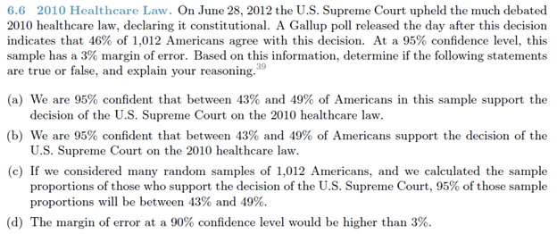

(a) TRUE - Given a margin of error of 3% and a point estimate of 46%, the interval for a 95% confidence interval works out to 43% and 49%.  
(b) TRUE - Given a margin of error of 3% and a point estimate of 46%, the interval works out to 43% - 49%. We can say that the interval of 43% to 49% would contain the true population mean 95% of the times.  
(c) FALSE - 95% of the times, the “Population” proportion would be between 43% and 49% and not the “Sample” Proportion.  
(d) FALSE - A lower confidence would mean a smaller Z score. A smaller Z score would lead to a smaller margin of error. The margin of error formula is :

margin_of_error = Z * standard_error

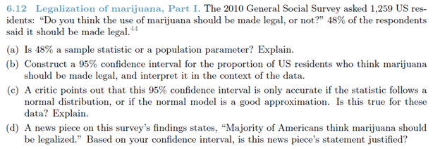

(a) It is stated “48% of the respondents”. This clearly means that it is a sample statistic.  
(b) Following are the calulations:

```r
n <- 1259
p <- 0.48

# Assuming that the samples are independent
success <- p * n
failure <- (1-p) * n

success > 10
```

```
## [1] TRUE
```

```r
failure > 10
```

```
## [1] TRUE
```

```r
# Success / failure condition is met with at least 10 successes and at least 10 failures

#calculating standard error

se <- sqrt( (p * (1-p) )/ n)
se
```

```
## [1] 0.01408022
```

```r
z <- qnorm(0.975)

# calculating Margin of Error

me <- z * (se)
me
```

```
## [1] 0.02759672
```

```r
# Construct the 95% Confidence Interval

CI <- data.frame(lower=p - me, upper=p + me)
CI
```

```
##       lower     upper
## 1 0.4524033 0.5075967
```

** The confidence interval is 0.4524033, 0.5075967**

3. The sample proportion of 0.48 is close to 0.5. So we can conclude that the distribution is nearly normal given that the data represents a binary state of 0 and 1.
4. The confidence interval has a upper bound of 0.5075967. If we were to interpret based on this upper bound, we see that it is slightly above 50%. This can be used to justify the statement (even though it seems inappropriate)

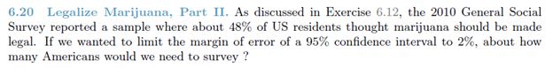

```r
p <- 0.48
me <- 0.02
z <- qnorm(0.975)

# calculating standard error for new margin of error
se <- me / z

# working backward for  n in se formula

n <- (p * (1-p)) / se^2
n
```

```
## [1] 2397.07
```

**A survey involving at least 2398 Americans would be needed to achieve a 2% margin of error for a 95% confidence interval**

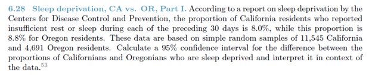

```r
p_California <- 0.08
p_Oregon <- 0.088
n_California <- 11545
n_Oregon <- 4691

# calculating the difference

p_Diff <- p_Oregon - p_California


# calculating the standard error for the difference.
SE <- sqrt( ((p_California * (1 - p_California)) / n_California) +  ((p_Oregon * (1 - p_Oregon)) / n_Oregon))

# calculating the margin of error for the difference.
me <- qnorm(0.975) * SE

# calculating the 95% confidence interval.
CI <- data.frame(lower=p_Diff - me, upper=p_Diff + me )
CI
```

```
##          lower      upper
## 1 -0.001497954 0.01749795
```

The 95% confidence interval of -0.001498 - 0.017498 contains 0. Hence we can conclude with a 95% confidence level that the proportions are not statistically different.

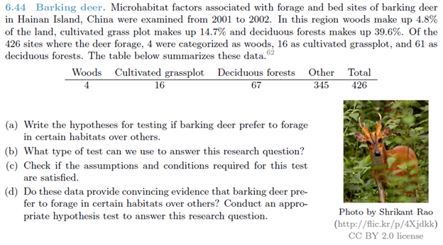

(a) The following is the hypothesis:

**H<sub>0</sub>:** The number of sites where the deers forage is distributed proportionately to the percentage of land.

**H<sub>A</sub>:** The number of sites where the deers forage is not distributed proportionately to the percentage of land.  
(b) We use a chi-square test for one way table.  
(c) Below is the table based on the proportions:

```r
wood_proportion <- round(426 * 0.048,2)
grassplot_proportion <- round(426 * 0.147,2)
forests_proportion <- round(426 * 0.396,2)
others_proportion <- round(426 * 0.409,2)
```

|  | wood | grassplot | Forests | others |
| --- | --- | --- | --- | --- |
| proportions | 20.45 | 62.62 | 168.7 | 174.23 |

To conduct the chi-square test the following conditions must be satisfied:

**Independence** - We assume that the cases are independent **Sample Size / Distribution** - All the cell counts are greater than 5 hence this conditions is also satisfied.  
(d) calculating the chi-square and p-value:

```r
Actual_sites <- c(4, 16, 67, 345)
Proportionate_sites <- c(20.45, 62.62, 168.70, 174.23)

k <- length(Actual_sites)
df <- k - 1

# Loop over the bin values to compute the chi2 test statistic
chi_square <- 0

for(i in 1:length(Actual_sites)){
  chi_square <- chi_square + ((Actual_sites[i] - Proportionate_sites[i])^2 / Proportionate_sites[i])
}

chi_square
```

```
## [1] 276.6286
```

```r
# looking up p value
p_value <- pchisq(chi_square, df=df, lower.tail=FALSE)
p_value
```

```
## [1] 1.135815e-59
```

**The chi-square value is so large the p-value is effectively 0. Therefore, we can conclude that there is evidence the barking deer forage in certain habitats over others.**

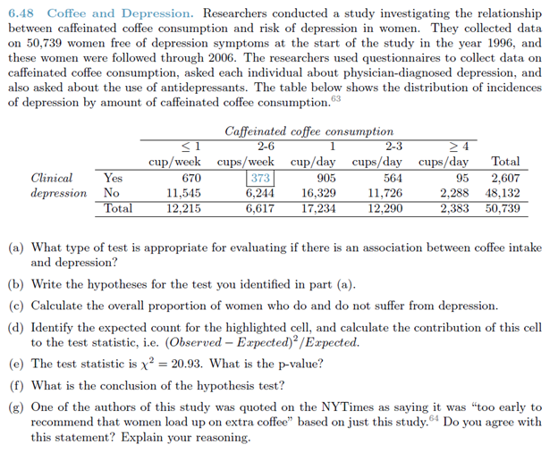

(a) A Chi-squared test for two-way tables is appropriate for evaluating if there is an association between coffee intake and depression.  
(b) The following is the hypothesis:

**H<sub>0</sub>:** There is no association between caffeinated coffee consumption and depression

**H<sub>A</sub>:** There is an association between caffeinated coffee consumption and depression  
(c) The following is the calculation:

```r
depression_yes <- 2607 / 50739
depression_yes
```

```
## [1] 0.05138059
```

```r
depression_no <- 1 - depression_yes
depression_no
```

```
## [1] 0.9486194
```

The overall proportion of women who suffer from depression is 0.05 and the overall proportion of women who do not suffer from depression is 0.95  
(d) Following are the calculations:

```r
k <- 5
df <- k - 1

expected_count <- round(depression_yes * 6617,2)
expected_count
```

```
## [1] 339.99
```

```r
cell_contribution <- (373 - expected_count)^2 / expected_count
cell_contribution
```

```
## [1] 3.204977
```

The exppected count is 339.99 and the cell contribution is 3.2049769.  
(e) We can lookup the p-value using the below code:

```r
p_value <- pchisq(20.93, df=df, lower.tail=FALSE)
p_value
```

```
## [1] 0.0003269507
```

The p value is 3.269507310^{-4}.

(f) Since the p value of 3.269507310^{-4} is less than 0.05 we reject the null hypothesis in favor of the alternative hypothesis. Hence we can conclude that there is an association between caffeinated coffee consumption and depression.  
(g) The study seems to be more observational in nature and not experimental. Given that the researchers had no control on the outcomes, there may have been other factors that may have led to the results. Hence I agree with the author.